# Estimation and testing for structural breaks with `mbreaks` package

Linh Nguyen, Yohei Yamamoto

# Estimation, inference and testing using mbreaks

## Econometric framework

The package `mbreaks` provides R users with minimum code but comprehensive functions to analyze structural breaks in linear regression models. The framework based on the econometric model of the following form:

There are 3 classes in the package, corresponding to 2 types of diagnostic tests provided and structural change model estimation based on $m$ breaks. These S3 classes have their modified `print()` functions to summarize key information. In summary:

- `sbtests`: S3 class returned from `dotest()` function. It includes summary of SupF test and DMax test with test statistics, critical values and summary tables which could be view in console via `print()` method or open in separated tab by `View()`
- `seqtests`: S3 class returned from `doseqtests()` function. It includes summary of sequential SupF test of $l+1$ versus $l$ breaks with test statistics, critical values and a summary table which could be view in console via `print()` method or open in separated tab by `View()`
- `model`: S3 class returned from estimation procedures above including `dofix()`, `doorder()`, `dosequa()`, and `dorepart()`. The class `model` contains numerous information which are summarized comprehensively into 3 main tables: i) break date estimates (estimated date and corresponding asymptotic confidence intervals), ii) regime-specific coefficients (estimates in each regime and corrected standard errors (SEs) based on assumptions made on errors structure) and iii) full-sample coefficient if $p>0$ (with estimates and corrected SEs). Besides the 3 main tables that include information about the estimated structural change model with $m$ breaks, `model` is a list contains fields (with majority of them are class `matrix`) which users can access by using operator `$` for further analysis in R (included information summarized in aforementioned above and other information such as fitted values, residuals and name of procedure used).

## Usage, arguments and examples

### Usage of main functions in `mbreaks`

The previous section introduces the framework that `mbreaks` package built on and summarize the classes of procedures available to users. In this section, we will illustrate the syntax of high-level functions and cover the arguments that users might want to customize to match the structural break model with data and desirable analysis.

The `mbreaks` package designs high-level functions to have identical arguments with default values recommended by the literature to save users the burden. Users can use `mdl()`, a comprehensive function that invoked all high-level functions explained in previous section:[^1]

```r
#load US ex-post exchange rate data
USrate = data(real)
#carry out all testing and estimating procedures via a single call
rate = mdl('rate',data=real)
#display the results from the procedures
rate
```

```
#> Number of max breaks specified:
#> -----------------------------------------------------
#> The number of breaks is estimated by BIC
#> Pure change model with 2 estimated breaks.
#> Minimum SSR = 455.950
#>
#> Estimated date:
#>         Break1  Break2
#> Date        47      79
#> 95% CI (37,50) (77,82)
#> 90% CI (40,49) (78,81)
#>
#> Estimated regime-specific coefficients:
#>                 Regime 1       Regime 2      Regime 3
#> Const (SE) 1.355 (0.155) -1.796 (0.511) 5.643 (0.603)
#>
#> No full sample regressors
#> -----------------------------------------------------
#> a) SupF tests against a fixed number of breaks
#>
#>         1 break 2 breaks 3 breaks 4 breaks 5 breaks
#> Sup F    57.906   43.014   33.323   24.771   18.326
#> 10% CV    7.040    6.280    5.210    4.410    3.470
#> 5% CV     8.580    7.220    5.960    4.990    3.910
#> 2.5% CV  10.180    8.140    6.720    5.510    4.340
#> 1% CV    12.290    9.360    7.600    6.190    4.910
#>
#> b) UDmax tests against an unknown number of breaks
#>
#>    UDMax 10% CV  5% CV 2.5% CV  1% CV
#> 1 57.906  7.460  8.880  10.390 12.370
#> -----------------------------------------------------
#> supF(l+1|l) tests using global optimizers under the null
#>
#>          supF(1|0) supF(2|1) supF(3|2) supF(4|3) supF(5|4)
#> Seq supF    57.906    33.927    14.725     0.033     0.000
#> 10% CV       7.040     8.510     9.410    10.040    10.580
#> 5% CV        8.580    10.130    11.140    11.830    12.250
#> 2.5% CV     10.180    11.860    12.660    13.400    13.890
#> 1% CV       12.290    13.890    14.800    15.280    15.760
#> -----------------------------------------------------
#> To access additional information about specific procedures
#>   (not included above), type stored variable name + '$' + procedure name
```

Users should find the syntax minimal (similar to `lm()` in `stats` package), with slight difference where users are required to specifically mention the name of $y$ variable in the data frame used. If no $z$ and $x$ regressors (if any) name specified, the program assumes this is a mean-shift model (as constant is included by default). The names of regressors must match the name used in data frame, otherwise errors will be displayed and execution halted. All of the arguments are set at default value but users are free to specify them to fit the analysis they are after. The section below will explain the arguments/options for the main functions to help users customize `mbreaks` as desirable:

### Options for high-level functions

- Any structural change model requires a trimming value $\epsilon_T$ where we assume any regime/segment within the sample must have minimum length $h = \lfloor \epsilon_T T\rfloor$. Users can modify $\epsilon_T$ in arguments passing to all high-level functions[^2] by setting `eps1 = s` where $0.05 \leq s \leq 0.5$..[^3] If the user input value for `eps1` is invalid, it will be set to default value `eps1=0.15`.
- Argument `m` specify maximum number of breaks considered in the model. This argument is automatically matched with `eps1` argument. If the program finds that `m` is invalid (non-positive or larger than allowed by sample size given trimming level `eps1`), it will be set automatically to maximal breaks allowed by sample size and specified trimming level `eps1`. The default value is `m=5`.
- The following options related to assumptions on structure of variance-covariance matrices for the errors $e_t$:
  - `robust`: Allow for heteroskedastic and autocorrelated in $e_t$. The default value is `robust=1`. If set to `0`, the errors are assumed to be martingale difference sequence.
  - `hetvar`: Allow the variance of the errors $e_t$ to be different across segments/regimes. This option imposed stricter assumptions on errors than `robust`, and is not allowed to be `0` when `robust=1`.
  - `prewhit`: Set to `1` if users want to prewhiten the residuals prior to estimating the long-run covariance matrix with an autoregressive (AR) process of order 1. The default value is `prewhit=1`.
- The following options related to assumptions on structure of variance-covariance matrices for the regressors $z_t$ and $x_t$ (if any):
  - `hetdat`: Set to `1` to allow the second moment matrices of $z_t$ and $x_t$ (if any) to be different across segments. Set to `0` otherwise. It is recommended to set `hetdat=1` for $p>0$. The default value is `hetdat=1`
  - `hetq`: Set to `1` to allow moment matrices of $z_t$ and $x_t$ (if any) to be different across segments. This is used in construction of the confidence interval for the break dates. If `hetq=0`, the moment matrices of the regressors are assumed to be identical across segments. The default value is `hetq=1`.
  - `hetomega`: Set to `1` to allow the long-run covariance matrix of $z_t u_t$ to be different across segments. Set to `0` otherwise. This is used in construction of the confidence interval for the break dates. The default value is `hetomega=1`.
- Additional options specifically for partial change model:[^4]
  - `maxi`: Maximum number of iterations if no convergence attained when running the iterative procedure to estimate partial change model. The default is `maxi=20`
  - `eps`: Criterion for convergence of the iterative procedure. The default value is `eps=0.0001`
  - `fixb`: Set to 1 if users intend to provide initial values for $\beta$, where the initial values are supplied as matrix `betaini` of size $(p \times 1)$. If `betaini` is invalid, the program will automatically set `fixb=0` and use OLS estimate for the initial values. The default value is `fixb=0`

There are two options available to all high-level functions: - `const`: Set to `1` to include constant in $z$ regressors. The default value is `const=1`. Users can turn off the constant for $z$ regressors by setting `const=0`. - `printd`: Set to `1` to print intermediate outputs from estimation procedures of the program to console. The default value is `printd=0`

Besides, there is an additional specific option for `doorder()` to specify which information criteria to use, `bic_opt`. If `bic_opt=1`, the BIC will be used as criterion to select the number of breaks, while `bic_opt=0`, the LWZ will be used in place.

## Empirical examples

### US real interest rate

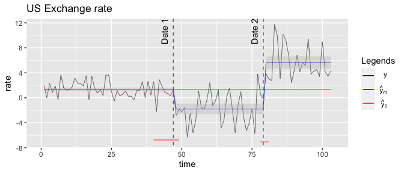

```r
#estimating the mean-shift model with BIC (the default option bic_opt=1, which use BIC as criterion)
rate_BIC = doorder('rate',data=real)
#NOTE: equivalent to rate$BIC; type rate$BIC to compare with new result


# visualization of estimated model with BIC (in the argument, we can replace rate$BIC with rate_BIC for exact same graph; recall that `$` is the operator to refer to field BIC in return list from mdl())
plot_model(rate$BIC, title = 'US Exchange rate', CI=0.90)
```

The `plot_model()` function takes any estimated structural break model class `model` estimated by `mbreaks` package and graph the following properties: - The observed $y$, fitted $\hat{y}_m$ values from a model with $m$ breaks (estimated or pre-specified depending on function called) and fitted $\hat{y}$ from a no break model (null model) for easy comparison - The estimated break dates with labels in chronological order and confidence interval depends on `CI` argument (which is either 0.9 or 0.95) for respective dates. - The confidence interval (also depends on argument `CI`) for fitted $\hat{y}_m$ which visualizes the corrected standard SEs for coefficient estimates.

To show flexibility of class `model` in the package, we can reproduce similar graph using information returned from stored variable `rate_BIC`.

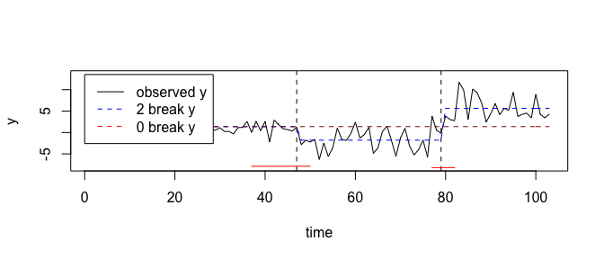

```r
  #collect model information
  m = rate_BIC$nbreak           #number of breaks
  y = rate_BIC$y                #vector of dependent var
  zreg = rate_BIC$z             #matrix of regressors with changing coefs
  date = rate_BIC$date          #estimated date
  fity = rate_BIC$fitted.values #fitted values of model
  bigT = length(y)
  #compute the null model
  fixb = solve((t(zreg) %*% zreg)) %*% t(zreg) %*% y
  fity_fix = zreg%*%fixb    #fitted values of null model


  #plots the model
  tx = seq(1,bigT,1)
  range_y = max(y)-min(y);
  plot(tx,y,type='l',col="black", xlab='time',ylab="y",
       ylim=c(min(y)-range_y/10,max(y)+range_y/10),lty=1)
  #plot fitted values series for break model
  lines(tx, fity,type='l', col="blue",lty=2)
  #plot fitted values series for null model
  lines(tx, fity_fix,type='l', col="dark red",lty=2)

  #plot estimated dates + CIs
  for (i in 1:m){
    abline(v=date[i,1],lty=2)
    if (rate_BIC$CI[i,1] < 0){rate_BIC$CI[i,1] = 0}
    if(rate_BIC$CI[i,2]>bigT){ rate_BIC$CI[i,2]=bigT}
    segments(rate_BIC$CI[i,1],min(y)*(12+i/m)/10,rate_BIC$CI[i,2],min(y)*(12+i/m)/10,lty=1,col='red')
  }

  legend(0,max(y)+range_y/10,legend=c("observed y",paste(m,'break y'),"0 break y"),
        lty=c(1,2,2), col=c("black","blue","red"), ncol=1)
```

```r
#x_t is GDP gap
  z_name = c('inflag','ygap','inffut')
  #we can invoke each test separately by using dotest() and doseqtests()
  supF_ygap = dotest('inf',z_name,data=nkpc,prewhit = 0)
  #z regressors' names are passed in the argument as an array, which equivalent to above argument call with z_name
  seqF_ygap = doseqtests('inf',c('inflag','ygap','inffut'),data=nkpc,prewhit = 0)
  #see test results
  supF_ygap
```

```
#>
#> a) SupF tests against a fixed number of breaks
#>
#>         1 break 2 breaks 3 breaks 4 breaks 5 breaks
#> Sup F    22.220    8.513   12.456   18.481   13.252
#> 10% CV   14.260   12.600   11.210    9.970    8.370
#> 5% CV    16.190   13.770   12.170   10.790    9.090
#> 2.5% CV  18.130   14.990   13.060   11.550    9.660
#> 1% CV    20.230   16.550   14.260   12.420   10.530
#>
#> b) UDmax tests against an unknown number of breaks
#>
#>    UDMax 10% CV  5% CV 2.5% CV  1% CV
#> 1 22.220 14.580 16.370  18.240 20.390
```

```r
  seqF_ygap
```

```
#>
#> supF(l+1|l) tests using global optimizers under the null
#>
#>          supF(1|0) supF(2|1) supF(3|2) supF(4|3) supF(5|4)
#> Seq supF    22.220    12.559    22.134     9.979     0.000
#> 10% CV      14.260    16.110    17.310    18.000    18.450
#> 5% CV       16.190    18.110    18.930    19.640    20.190
#> 2.5% CV     18.130    19.700    20.660    21.460    21.970
#> 1% CV       20.230    21.970    22.800    23.060    23.760
```

```r
#x_t is labor income share
  #or invoke all tests using mdl()
  nkpc_lbs = mdl('inf',c('inflag','lbs','inffut'),data=nkpc,prewhit = 0)
```

```
#>
#> There are no breaks selected by BICand estimation is skipped
#>
#> There are no breaks selected by LWZand estimation is skipped
#>
#> There are no breaks selected by KTand estimation is skipped
```

```r
  nkpc_lbs$sbtests
```

```
#>
#> a) SupF tests against a fixed number of breaks
#>
#>         1 break 2 breaks 3 breaks 4 breaks 5 breaks
#> Sup F    30.592    7.161    6.335   11.247    9.281
#> 10% CV   14.260   12.600   11.210    9.970    8.370
#> 5% CV    16.190   13.770   12.170   10.790    9.090
#> 2.5% CV  18.130   14.990   13.060   11.550    9.660
#> 1% CV    20.230   16.550   14.260   12.420   10.530
#>
#> b) UDmax tests against an unknown number of breaks
#>
#>    UDMax 10% CV  5% CV 2.5% CV  1% CV
#> 1 30.592 14.580 16.370  18.240 20.390
```

```r
  nkpc_lbs$seqtests
```

```
#>
#> supF(l+1|l) tests using global optimizers under the null
#>
#>          supF(1|0) supF(2|1) supF(3|2) supF(4|3) supF(5|4)
#> Seq supF    30.592    11.408     5.367    26.837     2.527
#> 10% CV      14.260    16.110    17.310    18.000    18.450
#> 5% CV       16.190    18.110    18.930    19.640    20.190
#> 2.5% CV     18.130    19.700    20.660    21.460    21.970
#> 1% CV       20.230    21.970    22.800    23.060    23.760
```

R Core Team. 2019. *R: A Language and Environment for Statistical Computing*. Vienna, Austria: R Foundation for Statistical Computing. https://www.R-project.org.

[^1]: Users can call independent functions to carry out specific procedures as outlined above instead of conducting all 6 main procedures provided by package via `mdl()`
[^2]: The high level functions are `mdl()`, `dofix()`, `dosequa()`, `dorepart()`, `doorder()`, `dotest()`, `doseqtests()`
[^3]: This argument is different from `eps` where `eps` sets the convergence criterion for iterative scheme when estimating partial change model.
[^4]: These options are unaffected the pure change model